# Course5 Reproducible Research - Assignment 2

Haoyi Wei

2022-12-22

# Instruction

Storms and other severe weather events can cause both public health and economic problems for communities and municipalities. Many severe events can result in fatalities, injuries, and property damage, and preventing such outcomes to the extent possible is a key concern.

This project involves exploring the U.S. National Oceanic and Atmospheric Administration’s (NOAA) storm database. This database tracks characteristics of major storms and weather events in the United States, including when and where they occur, as well as estimates of any fatalities, injuries, and property damage.

The basic goal of this assignment is to explore the NOAA Storm Database and answer some basic questions about severe weather events. You must use the database to answer the questions below and show the code for your entire analysis. Your analysis can consist of tables, figures, or other summaries. You may use any R package you want to support your analysis.

Questions

Your data analysis must address the following questions:

1. Across the United States, which types of events (as indicated in the EVTYPE variable) are most harmful with respect to population health?
2. Across the United States, which types of events have the greatest economic consequences?

Consider writing your report as if it were to be read by a government or municipal manager who might be responsible for preparing for severe weather events and will need to prioritize resources for different types of events. However, there is no need to make any specific recommendations in your report.

Requirements

For this assignment you will need some specific tools

RStudio: You will need RStudio to publish your completed analysis document to RPubs. You can also use RStudio to edit/write your analysis.

knitr: You will need the knitr package in order to compile your R Markdown document and convert it to HTML Document Layout

- Language: Your document should be written in English.
- Title: Your document should have a title that briefly summarizes your data analysis
- Synopsis: Immediately after the title, there should be a synopsis which describes and summarizes your analysis in at most 10 complete sentences.
- There should be a section titled Data Processing which describes (in words and code) how the data were loaded into R and processed for analysis. In particular, your analysis must start from the raw CSV file containing the data. You cannot do any preprocessing outside the document. - If preprocessing is time-consuming you may consider using the cache = TRUE option for certain code chunks.
- There should be a section titled Results in which your results are presented.
- You may have other sections in your analysis, but Data Processing and Results are required.
- The analysis document must have at least one figure containing a plot.
- Your analysis must have no more than three figures. Figures may have multiple plots in them (i.e. panel plots), but there cannot be more than three figures total.
- You must show all your code for the work in your analysis document. This may make the document a bit verbose, but that is okay. In general, you should ensure that echo = TRUE for every code chunk (this is the default setting in knitr).

# Explore the NOAA Storm Database

## Synopsis

The basic goal of this assignment is to expore the NOAA Storm Database and answer some basic questions about severe weather events. The data analyssi aims to addres two questions: (1) Across the United States, which types of events (as indicated in the EVTYPE variable) are most harmful with respect to population health? (2) Across the US,, which types of events have the greatest economic consequences?

## Loading and Processing the Raw Data

From the Coursera website, we obtained the storm dataset.

### Read the data

```r
library(readr)
storm_data <- read_csv("repdata-data-StormData.csv")
```

After reading in the data, we check the first few rows in the datasets

```r
dim(storm_data)
```

```
## [1] 902297     37
```

```r
head(storm_data)
```

```
## # A tibble: 6 × 37
##   STATE__ BGN_DATE   BGN_T…¹ TIME_…² COUNTY COUNT…³ STATE EVTYPE BGN_R…⁴ BGN_AZI
##     <dbl> <chr>      <chr>   <chr>    <dbl> <chr>   <chr> <chr>    <dbl> <chr>
## 1       1 4/18/1950… 0130    CST         97 MOBILE  AL    TORNA…       0 <NA>
## 2       1 4/18/1950… 0145    CST          3 BALDWIN AL    TORNA…       0 <NA>
## 3       1 2/20/1951… 1600    CST         57 FAYETTE AL    TORNA…       0 <NA>
## 4       1 6/8/1951 … 0900    CST         89 MADISON AL    TORNA…       0 <NA>
## 5       1 11/15/195… 1500    CST         43 CULLMAN AL    TORNA…       0 <NA>
## 6       1 11/15/195… 2000    CST         77 LAUDER… AL    TORNA…       0 <NA>
## # … with 27 more variables: BGN_LOCATI <chr>, END_DATE <chr>, END_TIME <chr>,
## #   COUNTY_END <dbl>, COUNTYENDN <lgl>, END_RANGE <dbl>, END_AZI <chr>,
## #   END_LOCATI <chr>, LENGTH <dbl>, WIDTH <dbl>, F <dbl>, MAG <dbl>,
## #   FATALITIES <dbl>, INJURIES <dbl>, PROPDMG <dbl>, PROPDMGEXP <chr>,
## #   CROPDMG <dbl>, CROPDMGEXP <chr>, WFO <chr>, STATEOFFIC <chr>,
## #   ZONENAMES <chr>, LATITUDE <dbl>, LONGITUDE <dbl>, LATITUDE_E <dbl>,
## #   LONGITUDE_ <dbl>, REMARKS <chr>, REFNUM <dbl>, and abbreviated variable …
## # ℹ Use `colnames()` to see all variable names
```

### Clean the data

```r
tidy_storm <- storm_data[,c('EVTYPE','FATALITIES','INJURIES', 'PROPDMG', 'PROPDMGEXP', 'CROPDMG', 'CROPDMGEXP')]
head(tidy_storm)
```

```
## # A tibble: 6 × 7
##   EVTYPE  FATALITIES INJURIES PROPDMG PROPDMGEXP CROPDMG CROPDMGEXP
##   <chr>        <dbl>    <dbl>   <dbl> <chr>        <dbl> <chr>
## 1 TORNADO          0       15    25   K                0 <NA>
## 2 TORNADO          0        0     2.5 K                0 <NA>
## 3 TORNADO          0        2    25   K                0 <NA>
## 4 TORNADO          0        2     2.5 K                0 <NA>
## 5 TORNADO          0        2     2.5 K                0 <NA>
## 6 TORNADO          0        6     2.5 K                0 <NA>
```

```r
str(tidy_storm)
```

```
## tibble [902,297 × 7] (S3: tbl_df/tbl/data.frame)
##  $ EVTYPE    : chr [1:902297] "TORNADO" "TORNADO" "TORNADO" "TORNADO" ...
##  $ FATALITIES: num [1:902297] 0 0 0 0 0 0 0 0 1 0 ...
##  $ INJURIES  : num [1:902297] 15 0 2 2 2 6 1 0 14 0 ...
##  $ PROPDMG   : num [1:902297] 25 2.5 25 2.5 2.5 2.5 2.5 2.5 25 25 ...
##  $ PROPDMGEXP: chr [1:902297] "K" "K" "K" "K" ...
##  $ CROPDMG   : num [1:902297] 0 0 0 0 0 0 0 0 0 0 ...
##  $ CROPDMGEXP: chr [1:902297] NA NA NA NA ...
```

## Results

### Question 1

Across the United States, which types of events (as indicated in the EVTYPE variable) are most harmful with respect to population health?

```r
# check number of missing values
sum(is.na(tidy_storm[,c('FATALITIES','INJURIES')]))
```

```
## [1] 0
```

```r
# make the health demage dataset
library(dplyr)
library(tidyr)
tidy_q1 <- tidy_storm %>%
          group_by(EVTYPE) %>%
          summarize(fatalities = sum(FATALITIES), injuries= sum(INJURIES), .groups='drop') %>%
          mutate(total = fatalities + injuries) %>%
          select(EVTYPE, total,fatalities, injuries) %>%
          arrange(-total,-fatalities,-injuries) %>%
          slice(1:10) %>% # select top ten events
          mutate(evtype=factor(EVTYPE, levels=EVTYPE)) %>%
          gather(key = Type, value = Value,total,fatalities,injuries)
```

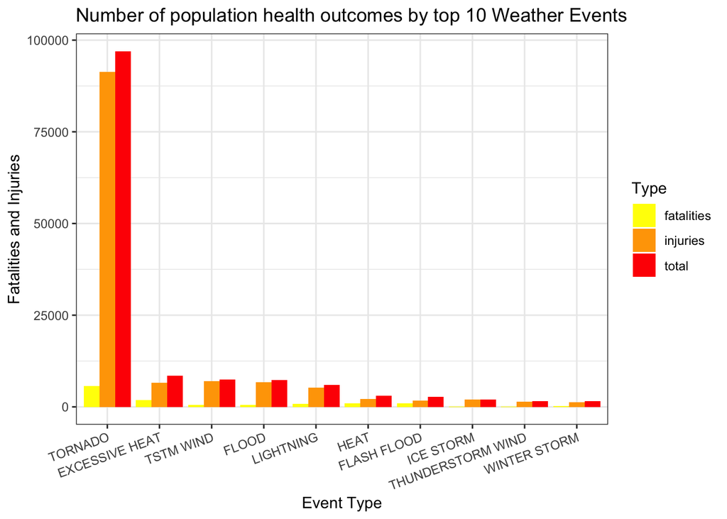

```r
# make the plot
library(ggplot2)

ggplot(tidy_q1, aes(evtype, Value, fill=Type)) +
          geom_bar(position="dodge",stat="identity") +
          theme_bw() +
          theme(axis.text.x= element_text(angle=20, vjust=1, hjust=1)) +
          xlab("Event Type") +
          ylab("Fatalities and Injuries") +
          ggtitle("Number of population health outcomes by top 10 Weather Events") +
          scale_fill_manual(values=c("yellow","orange","red"))
```

### Question 2

```r
unique(storm_data$PROPDMGEXP)
```

```
##  [1] "K" "M" NA  "B" "m" "+" "0" "5" "6" "?" "4" "2" "3" "h" "7" "H" "-" "1" "8"
```

```r
unique(storm_data$CROPDMGEXP)
```

```
## [1] NA  "M" "K" "m" "B" "?" "0" "k" "2"
```

create a function to clean the property damage data

```r
cost <- function(x) {
  if (x == "H")
    1E-4
  else if (x == "K")
    1E-3
  else if (x == "M")
    1
  else if (x == "B")
    1E3
  else
    1-6
}
```

make the plot

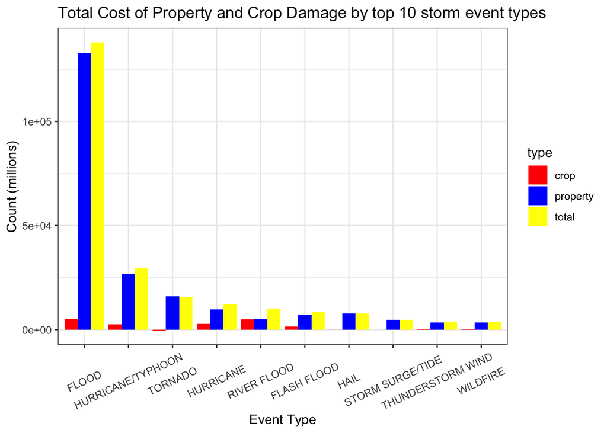

```r
tidy_q2 <- tidy_storm %>%
          filter(is.na(CROPDMGEXP)!=1 & is.na(PROPDMGEXP)!=1) %>%
    mutate(prop_dmg = PROPDMG*sapply(PROPDMGEXP, FUN = cost),
           crop_dmg = CROPDMG*sapply(CROPDMGEXP, FUN = cost), .keep="unused") %>%
    group_by(EVTYPE) %>%
    summarize(property = sum(prop_dmg), crop = sum(crop_dmg), .groups='drop') %>%
    arrange(desc(property), desc(crop)) %>%
    mutate(total=property+crop) %>%
    slice(1:10) %>%
    gather(key = type, value = value, total, property, crop)

ggplot(data=tidy_q2, aes(reorder(EVTYPE, -value), value, fill=type)) +
  geom_bar(position = "dodge", stat="identity") +
  labs(x="Event Type", y="Count (millions)") +
  theme_bw() +
  theme(axis.text.x = element_text(angle = 25, vjust=0.5)) +
  ggtitle("Total Cost of Property and Crop Damage by top 10 storm event types") +
  scale_fill_manual(values=c("red", "blue","yellow"))
```

## Reference

Roger D. Peng’s Example